# Tidymodels: Workflows

Luca Baggi

# Load packages & set seed

For reproducibility purposes:

```r
set.seed(42)
```

Load the packages:

```r
library(tidymodels)

# helper packages
library(nycflights13)    # for flight data
library(skimr)           # for variable summaries
```

# Data preprocessing

Also, how to use `dplyr` at the next level, ft. Mark Khun:

```r
flight_data <-
  flights %>%
  mutate(
    # convert arrival delay to a factor:
    arr_delay = factor(ifelse(arr_delay >= 30, 'late', 'on_time')),
    # date, for future use:
    date = as.Date(time_hour)
  ) %>%
  # perform a inner_join to include weather data
  inner_join(weather, by = c('origin', 'time_hour')) %>%
  # retain the columns that will be used:
  select(dep_time, flight, origin, dest, air_time, distance,
         carrier, date, arr_delay, time_hour) %>%
  # exclude missing data:
  na.omit() %>%
  # mutate qualitative columns as factors:
  mutate_if(is.character, as.factor)
```

Notes for me: 1. `ifelse()` is smarter than `replace`; 2. Use multiple lines statements within `mutate()` to change multiple lines at a time; 3. `joins()` references are [here](https://www.rdocumentation.org/packages/dplyr/versions/0.7.8/topics/join); 4. Use `na.omit()` more often; 5. Remember to `mutate_if()` to turn characters into factors.

To count the share of flights which arrived late, just:

| arr_delay | n | prop |
| --- | --- | --- |
| late | 52540 | 0.1612552 |
| on_time | 273279 | 0.8387448 |

This works too, albeit less elegant.

```r
flight_data %>%
  select(arr_delay) %>%
  table() %>%
  prop.table()
```

```
.
     late   on_time
0.1612552 0.8387448
```

# Data Splitting

```r
data_split <- initial_split(flight_data)

train_data <- training(data_split)
test_data <- testing(data_split)
```

# Create recipes and roles

Roles are customarily given to label some variables. For example, we might build this recipe for our data. In this way, it won’t be included in the model fitting! Variables can be retained from the data when creating a model.

```
flight_recipe <- train_data %>%
  recipe(arr_delay ~ .) %>%
  update_role(flight, time_hour, new_role = 'ID')
```

Default roles are `predictor` and response, so updating the role we effectively take them out of the formula. In other words, we are changing their `selector`!

Then we can engineer many more variables thanks to `recipes`! `step_*` are numerous!

## Feature engineering

Much better than turning the date in numeric, we can add more `step`s to the recipe.

As a reminder, we can use:

```
flight_data %>%
  distict(date) %>% # select every unique instance of the argument
  mutate(numeric_date = as.numeric(date))
```

Let’s manipulate data with `recipes`. We will also use `timeDate::listHolidays()`, whose docs are [here](https://rdrr.io/cran/timeDate/man/holiday-Listing.html).

```r
flight_recipe <- train_data %>%
  recipe(arr_delay ~ .) %>%
  update_role(flight, time_hour, new_role = 'ID') %>%
  # step_date() creates new features starting from date objects
  # features requires a concatenation of 'dow' (day of week), 'month' or 'year'...
  step_date(date, features = c('dow', 'month', 'week')) %>%
  # step_holiday will create a binary variable for holidays!
  # it requires a c concatenation, but one can also fill it with the whole holidays:
  step_holiday(date, holidays = timeDate::listHolidays('US')) %>%
  # step_date does not remove the argument, so we have to do it manually
  step_rm(date) %>%
  # deal with dummies:
  step_dummy(all_nominal(), -all_outcomes()) %>%
  # finally, remove zero-variance dummies, i.e., those that occur only once:
  step_zv(all_predictors())
```

References for dummy variables can be found in [this book](https://bookdown.org/max/FES/creating-dummy-variables-for-unordered-categories.html).

# Model Fitting

We start by specifying the model: fitting, as usual, will be done later.

```r
logistic_model <- logistic_reg() %>%
  set_engine('glm')
```

Then we create a `workflow`:

```r
flights_workflow
```

```
══ Workflow ═════════════════════════════════════════════════════════════════════════════
Preprocessor: Recipe
Model: logistic_reg()

── Preprocessor ─────────────────────────────────────────────────────────────────────────
5 Recipe Steps

● step_date()
● step_holiday()
● step_rm()
● step_dummy()
● step_zv()

── Model ────────────────────────────────────────────────────────────────────────────────
Logistic Regression Model Specification (classification)

Computational engine: glm
```

Then we fit the model:

```r
flights_fit <- flights_workflow %>%
  fit(data = train_data)
```

Then we can extract both the recipe and the fit with the helper commands.

| term | estimate | std.error | statistic | p.value |
| --- | --- | --- | --- | --- |
| (Intercept) | 4.007756892 | 2.735975e+00 | 1.46483686 | 1.429654e-01 |
| dep_time | -0.001674369 | 1.411091e-05 | -118.65776364 | 0.000000e+00 |
| air_time | -0.043458897 | 5.605043e-04 | -77.53535295 | 0.000000e+00 |
| distance | 0.006887705 | 1.506518e-03 | 4.57193818 | 4.832335e-06 |
| date_week | -0.025664120 | 4.907927e-03 | -5.22911593 | 1.703225e-07 |
| date_USChristmasDay | 1.140528007 | 1.695211e-01 | 6.72794233 | 1.720791e-11 |
| date_USColumbusDay | 0.657118699 | 1.710168e-01 | 3.84242105 | 1.218266e-04 |
| date_USCPulaskisBirthday | 0.618737101 | 1.342138e-01 | 4.61008619 | 4.025021e-06 |
| date_USDecorationMemorialDay | 0.400551020 | 1.161947e-01 | 3.44723966 | 5.663459e-04 |
| date_USElectionDay | 0.803622963 | 1.820730e-01 | 4.41374080 | 1.015996e-05 |

[output cut: 149 more lines]

We can also use other methods of `broom`:

| null.deviance | df.null | logLik | AIC | BIC | deviance | df.residual | nobs |
| --- | --- | --- | --- | --- | --- | --- | --- |
| 216032.3 | 244364 | -91979.88 | 184277.8 | 185932.4 | 183959.8 | 244206 | 244365 |

# Predictions

Are much, much faster: just a function call!

| .pred_class |
| --- |
| on_time |
| on_time |
| on_time |
| on_time |
| on_time |
| on_time |
| on_time |
| on_time |
| on_time |
| on_time |

[output cut: 990 more lines]

As the result is a `tibble`, we can `bind_cols` to a new variable!

| .pred_late | .pred_on_time | .pred_class | arr_delay | time_hour | flight |
| --- | --- | --- | --- | --- | --- |
| 6.299932e-02 | 0.9370007 | on_time | on_time | 2013-01-01 05:00:00 | 1545 |
| 4.177853e-02 | 0.9582215 | on_time | on_time | 2013-01-01 06:00:00 | 507 |
| 4.771383e-02 | 0.9522862 | on_time | on_time | 2013-01-01 06:00:00 | 5708 |
| 2.851067e-02 | 0.9714893 | on_time | on_time | 2013-01-01 06:00:00 | 79 |
| 5.263334e-02 | 0.9473667 | on_time | on_time | 2013-01-01 06:00:00 | 301 |
| 1.858755e-01 | 0.8141245 | on_time | late | 2013-01-01 06:00:00 | 707 |
| 3.345910e-02 | 0.9665409 | on_time | on_time | 2013-01-01 06:00:00 | 371 |
| 1.795674e-02 | 0.9820433 | on_time | on_time | 2013-01-01 06:00:00 | 1895 |
| 1.015689e-01 | 0.8984311 | on_time | late | 2013-01-01 06:00:00 | 3768 |
| 4.702719e-02 | 0.9529728 | on_time | on_time | 2013-01-01 06:00:00 | 303 |

[output cut: 990 more lines]

# Model Evaluation

Let’s start with my beloved confusion matrix:

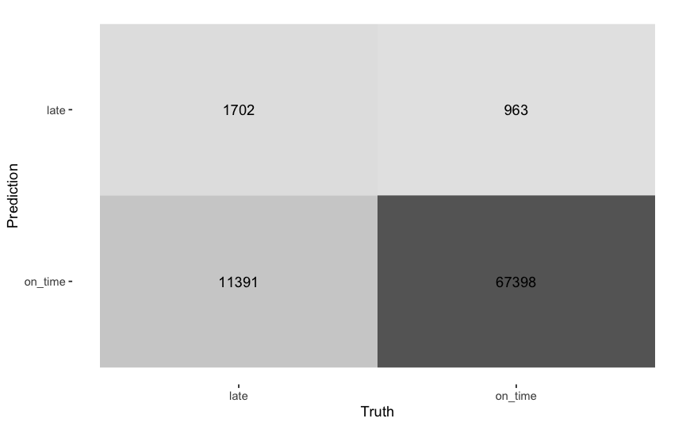

Let’s use the receiver operating characteristic (ROC) curve.

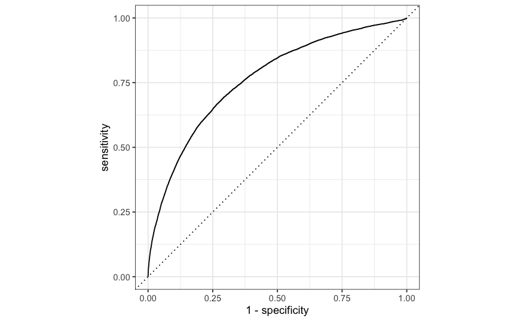

```r
predictions %>%
  roc_curve(arr_delay, .pred_late) %>%
  autoplot()
```

```r
# return the measure of the ROC area under the curve (AUC)
predictions %>%
  roc_auc(arr_delay, .pred_late)
```

| .metric | .estimator | .estimate |
| --- | --- | --- |
| roc_auc | binary | 0.7643593 |